# Project4_FelixCamachoCriado

### Project 4: Identifying fraud from Enron

## Author: Félix Carlos Camacho Criado

- Summary
- Question 1
- Question 2
- Question 3
- Question 4
- Question 5
- Question 6

### Summary:

The Enron Scandal surfaced in October 2001 when it was revealed that America's seventh largest company was involved in corporate corruption and accounting fraud. The scandal surrounding the Enron energy company included political implications due to Enron's close links with the White House. The Enron scandal eventually led to the bankruptcy of the corporation together with and the dissolution of the auditing company Arthur Andersen. ENRON shareholders lost $74 billion leading up to its bankruptcy, and its employees lost their jobs and billions in pension benefits.

### Q1: Summarize for us the goal of this project and how machine learning is useful in trying to accomplish it. As part of your answer, give some background on the dataset and how it can be used to answer the project question. Were there any outliers in the data when you got it, and how did you handle those? [relevant rubric items: “data exploration”, “outlier investigation”]

### Goal

The goal of this project is to identify person of interest, POIs, among the Enron company employees who could have committed fraud in their work assignments. To achieve this, some inputs have been provided, on the one hand a significant amount of data from emails from the Enron employees such as the content of the emails, who is the sender or who is the receiver. On the other hand, financial information which inform about the payments done to relevant Enron employees such as salary, bonus or long term incentives. The application of a machine learning model will definetely help to identify those persons of interest based on financial and data from emails.

### Data Exploration

First step, as usual, will be to have a look into the data in order to familiarize myself with them and idetify if there is any error or rate value in the dataset which could affect to the final result. So, in this case these errors or non logical values would be removed.

The Enron email and financial data were combined into a dictionary, where each key-value pair in the dictionary corresponds to one person. The dictionary key is the person's name, and the value is another dictionary, which contains the names of all the features and their values for that person. The features in the data fall into three major types, namely financial features, email features and POI labels.

```python
#importing libraries

import sys
import pandas as pd
import numpy as np
import pickle
import matplotlib.pyplot as plt
from sklearn.neighbors import KNeighborsClassifier
from sklearn.ensemble import AdaBoostClassifier
from sklearn.ensemble import RandomForestClassifier
from sklearn.tree import DecisionTreeClassifier
from sklearn import preprocessing
from time import time
from sklearn.model_selection import GridSearchCV
from sklearn.metrics import *
from sklearn.svm import SVC
from sklearn.feature_selection import SelectKBest
from sklearn import tree
from sklearn.naive_bayes import GaussianNB
from warnings import simplefilter
from sklearn.metrics import  confusion_matrix
simplefilter(action='ignore', category=FutureWarning)
import warnings
warnings.filterwarnings('always')

sys.path.append("../tools/")

from feature_format import featureFormat, targetFeatureSplit  #using featureformat.py stored in /tools folder.
from tester import dump_classifier_and_data
```

```python
with open("final_project_dataset.pkl", "r") as data_file:
    data_dict = pickle.load(data_file)
```

```python
#converting dict to dataframe in order to facilitate the data exploration.
df = pd.DataFrame.from_dict(data_dict, orient = 'index')
df.head()
```

|  | salary | to_messages | deferral_payments | total_payments | exercised_stock_options | bonus | restricted_stock | shared_receipt_with_poi | restricted_stock_deferred | total_stock_value | ... | loan_advances | from_messages | other | from_this_person_to_poi | poi | director_fees | deferred_income | long_term_incentive | email_address | from_poi_to_this_person |
| --- | --- | --- | --- | --- | --- | --- | --- | --- | --- | --- | --- | --- | --- | --- | --- | --- | --- | --- | --- | --- | --- |
| ALLEN PHILLIP K | 201955 | 2902 | 2869717 | 4484442 | 1729541 | 4175000 | 126027 | 1407 | -126027 | 1729541 | ... | NaN | 2195 | 152 | 65 | False | NaN | -3081055 | 304805 | phillip.allen@enron.com | 47 |
| BADUM JAMES P | NaN | NaN | 178980 | 182466 | 257817 | NaN | NaN | NaN | NaN | 257817 | ... | NaN | NaN | NaN | NaN | False | NaN | NaN | NaN | NaN | NaN |
| BANNANTINE JAMES M | 477 | 566 | NaN | 916197 | 4046157 | NaN | 1757552 | 465 | -560222 | 5243487 | ... | NaN | 29 | 864523 | 0 | False | NaN | -5104 | NaN | james.bannantine@enron.com | 39 |
| BAXTER JOHN C | 267102 | NaN | 1295738 | 5634343 | 6680544 | 1200000 | 3942714 | NaN | NaN | 10623258 | ... | NaN | NaN | 2660303 | NaN | False | NaN | -1386055 | 1586055 | NaN | NaN |
| BAY FRANKLIN R | 239671 | NaN | 260455 | 827696 | NaN | 400000 | 145796 | NaN | -82782 | 63014 | ... | NaN | NaN | 69 | NaN | False | NaN | -201641 | NaN | frank.bay@enron.com | NaN |

5 rows × 21 columns

After loading the file, I noticed that NaN values in the columns were string data type so, first of all I replace them for NaN values in order to have a clearer view about the missing values in the dataset.

```python
df = df.replace("NaN", np.NaN)
df.info()
```

```
<class 'pandas.core.frame.DataFrame'>
Index: 146 entries, ALLEN PHILLIP K to YEAP SOON
Data columns (total 21 columns):
salary                       95 non-null float64
to_messages                  86 non-null float64
deferral_payments            39 non-null float64
total_payments               125 non-null float64
exercised_stock_options      102 non-null float64
bonus                        82 non-null float64
restricted_stock             110 non-null float64
shared_receipt_with_poi      86 non-null float64
restricted_stock_deferred    18 non-null float64
total_stock_value            126 non-null float64
expenses                     95 non-null float64
loan_advances                4 non-null float64
from_messages                86 non-null float64
other                        93 non-null float64
from_this_person_to_poi      86 non-null float64
poi                          146 non-null bool
director_fees                17 non-null float64
deferred_income              49 non-null float64
long_term_incentive          66 non-null float64
email_address                111 non-null object
from_poi_to_this_person      86 non-null float64
dtypes: bool(1), float64(19), object(1)
memory usage: 24.1+ KB
```

I can find in the dataset information from 146 number of data points, almost all data point belongs to Enron employee and the variables give financial information about them. POI variable determine who is a person of interest or not.

```python
df.describe()
```

|  | salary | to_messages | deferral_payments | total_payments | exercised_stock_options | bonus | restricted_stock | shared_receipt_with_poi | restricted_stock_deferred | total_stock_value | expenses | loan_advances | from_messages | other | from_this_person_to_poi | director_fees | deferred_income | long_term_incentive | from_poi_to_this_person |
| --- | --- | --- | --- | --- | --- | --- | --- | --- | --- | --- | --- | --- | --- | --- | --- | --- | --- | --- | --- |
| count | 9.500000e+01 | 86.000000 | 3.900000e+01 | 1.250000e+02 | 1.020000e+02 | 8.200000e+01 | 1.100000e+02 | 86.000000 | 1.800000e+01 | 1.260000e+02 | 9.500000e+01 | 4.000000e+00 | 86.000000 | 9.300000e+01 | 86.000000 | 1.700000e+01 | 4.900000e+01 | 6.600000e+01 | 86.000000 |
| mean | 5.621943e+05 | 2073.860465 | 1.642674e+06 | 5.081526e+06 | 5.987054e+06 | 2.374235e+06 | 2.321741e+06 | 1176.465116 | 1.664106e+05 | 6.773957e+06 | 1.087289e+05 | 4.196250e+07 | 608.790698 | 9.190650e+05 | 41.232558 | 1.668049e+05 | -1.140475e+06 | 1.470361e+06 | 64.895349 |
| std | 2.716369e+06 | 2582.700981 | 5.161930e+06 | 2.906172e+07 | 3.106201e+07 | 1.071333e+07 | 1.251828e+07 | 1178.317641 | 4.201494e+06 | 3.895777e+07 | 5.335348e+05 | 4.708321e+07 | 1841.033949 | 4.589253e+06 | 100.073111 | 3.198914e+05 | 4.025406e+06 | 5.942759e+06 | 86.979244 |
| min | 4.770000e+02 | 57.000000 | -1.025000e+05 | 1.480000e+02 | 3.285000e+03 | 7.000000e+04 | -2.604490e+06 | 2.000000 | -7.576788e+06 | -4.409300e+04 | 1.480000e+02 | 4.000000e+05 | 12.000000 | 2.000000e+00 | 0.000000 | 3.285000e+03 | -2.799289e+07 | 6.922300e+04 | 0.000000 |
| 25% | 2.118160e+05 | 541.250000 | 8.157300e+04 | 3.944750e+05 | 5.278862e+05 | 4.312500e+05 | 2.540180e+05 | 249.750000 | -3.896218e+05 | 4.945102e+05 | 2.261400e+04 | 1.600000e+06 | 22.750000 | 1.215000e+03 | 1.000000 | 9.878400e+04 | -6.948620e+05 | 2.812500e+05 | 10.000000 |
| 50% | 2.599960e+05 | 1211.000000 | 2.274490e+05 | 1.101393e+06 | 1.310814e+06 | 7.693750e+05 | 4.517400e+05 | 740.500000 | -1.469750e+05 | 1.102872e+06 | 4.695000e+04 | 4.176250e+07 | 41.000000 | 5.238200e+04 | 8.000000 | 1.085790e+05 | -1.597920e+05 | 4.420350e+05 | 35.000000 |
| 75% | 3.121170e+05 | 2634.750000 | 1.002672e+06 | 2.093263e+06 | 2.547724e+06 | 1.200000e+06 | 1.002370e+06 | 1888.250000 | -7.500975e+04 | 2.949847e+06 | 7.995250e+04 | 8.212500e+07 | 145.500000 | 3.620960e+05 | 24.750000 | 1.137840e+05 | -3.834600e+04 | 9.386720e+05 | 72.250000 |
| max | 2.670423e+07 | 15149.000000 | 3.208340e+07 | 3.098866e+08 | 3.117640e+08 | 9.734362e+07 | 1.303223e+08 | 5521.000000 | 1.545629e+07 | 4.345095e+08 | 5.235198e+06 | 8.392500e+07 | 14368.000000 | 4.266759e+07 | 609.000000 | 1.398517e+06 | -8.330000e+02 | 4.852193e+07 | 528.000000 |

There are some significant differences between the maximum values of some variables such salary or total_payments I will deep into details in the next steps.

```python
df_r = df.rename_axis('employee').reset_index() #having a look into the feature completeness
```

```python
df_total = df_r.isnull().sum().sort_values(ascending=False)
percent = (df_r.isnull().sum()/df_r.isnull().count()).sort_values(ascending=False)
missing_data = pd.concat([df_total, percent], axis=1, keys=['Num', 'Percent'])
missing_data.head(10)
```

|  | Num | Percent |
| --- | --- | --- |
| loan_advances | 142 | 0.972603 |
| director_fees | 129 | 0.883562 |
| restricted_stock_deferred | 128 | 0.876712 |
| deferral_payments | 107 | 0.732877 |
| deferred_income | 97 | 0.664384 |
| long_term_incentive | 80 | 0.547945 |
| bonus | 64 | 0.438356 |
| from_this_person_to_poi | 60 | 0.410959 |
| from_messages | 60 | 0.410959 |
| to_messages | 60 | 0.410959 |

The variables present a different level of completeness.

### Outliers

```python
df_r = df.drop(columns = ['poi']) #For the outlier detection I don't want to work with the label column.
df_r.sort_values(by=['salary'], ascending = False).head()
```

|  | salary | to_messages | deferral_payments | total_payments | exercised_stock_options | bonus | restricted_stock | shared_receipt_with_poi | restricted_stock_deferred | total_stock_value | expenses | loan_advances | from_messages | other | from_this_person_to_poi | director_fees | deferred_income | long_term_incentive | email_address | from_poi_to_this_person |
| --- | --- | --- | --- | --- | --- | --- | --- | --- | --- | --- | --- | --- | --- | --- | --- | --- | --- | --- | --- | --- |
| TOTAL | 26704229.0 | NaN | 32083396.0 | 309886585.0 | 311764000.0 | 97343619.0 | 130322299.0 | NaN | -7576788.0 | 434509511.0 | 5235198.0 | 83925000.0 | NaN | 42667589.0 | NaN | 1398517.0 | -27992891.0 | 48521928.0 | NaN | NaN |
| SKILLING JEFFREY K | 1111258.0 | 3627.0 | NaN | 8682716.0 | 19250000.0 | 5600000.0 | 6843672.0 | 2042.0 | NaN | 26093672.0 | 29336.0 | NaN | 108.0 | 22122.0 | 30.0 | NaN | NaN | 1920000.0 | jeff.skilling@enron.com | 88.0 |
| LAY KENNETH L | 1072321.0 | 4273.0 | 202911.0 | 103559793.0 | 34348384.0 | 7000000.0 | 14761694.0 | 2411.0 | NaN | 49110078.0 | 99832.0 | 81525000.0 | 36.0 | 10359729.0 | 16.0 | NaN | -300000.0 | 3600000.0 | kenneth.lay@enron.com | 123.0 |
| FREVERT MARK A | 1060932.0 | 3275.0 | 6426990.0 | 17252530.0 | 10433518.0 | 2000000.0 | 4188667.0 | 2979.0 | NaN | 14622185.0 | 86987.0 | 2000000.0 | 21.0 | 7427621.0 | 6.0 | NaN | -3367011.0 | 1617011.0 | mark.frevert@enron.com | 242.0 |
| PICKERING MARK R | 655037.0 | 898.0 | NaN | 1386690.0 | 28798.0 | 300000.0 | NaN | 728.0 | NaN | 28798.0 | 31653.0 | 400000.0 | 67.0 | NaN | 0.0 | NaN | NaN | NaN | mark.pickering@enron.com | 7.0 |

I can identify SKILLING JEFFREY K and LAY KENNETH L like the employees with the highest salary (which is an understandable thing as they were the founders of Enron) But "TOTAL" seems to be a summatory of all salaries and it doesn't offer any additional value . I will remove it.

```python
df_t = df.transpose() #having a look into the employee's data.
```

```python
df_total = df_t.isnull().sum().sort_values(ascending=False)
percent = (df_t.isnull().sum()/df_t.isnull().count()).sort_values(ascending=False)
missing_data = pd.concat([df_total, percent], axis=1, keys=['Num', 'Percent'])
missing_data.head(5)
```

|  | Num | Percent |
| --- | --- | --- |
| LOCKHART EUGENE E | 20 | 0.952381 |
| GRAMM WENDY L | 18 | 0.857143 |
| WROBEL BRUCE | 18 | 0.857143 |
| WHALEY DAVID A | 18 | 0.857143 |
| THE TRAVEL AGENCY IN THE PARK | 18 | 0.857143 |

Checking data completeness per employee it shows some relevant information. The info from the employee called LOCKHART EUGENE E are NaN values and I could find another row which are suspicious of not being an employee like "THE TRAVEL AGENCY IN THE PARK". I will not consider this both rows.

```python
df = pd.DataFrame.from_dict(data_dict, orient = 'index')
df.replace(to_replace='NaN', value=0, inplace=True)
```

```python
len(df)
```

```
146
```

```python
df = df.drop(['TOTAL', 'THE TRAVEL AGENCY IN THE PARK','LOCKHART EUGENE E'])
```

```python
data_dict = df.transpose().to_dict()
```

```python
print 'Number of data points:',len(df)
```

```
Number of data points: 143
```

```python
poi = len(df[df['poi'] == True])

print 'Number of POIs:' ,poi
```

```
Number of POIs: 18
```

```python
print 'Number of non POIs:' , len(data_dict)-poi
```

```
Number of non POIs: 125
```

#### Q2: What features did you end up using in your POI identifier, and what selection process did you use to pick them? Did you have to do any scaling? Why or why not? As part of the assignment, you should attempt to engineer your own feature that does not come ready-made in the dataset -- explain what feature you tried to make, and the rationale behind it. (You do not necessarily have to use it in the final analysis, only engineer and test it.) In your feature selection step, if you used an algorithm like a decision tree, please also give the feature importances of the features that you use, and if you used an automated feature selection function like SelectKBest, please report the feature scores and reasons for your choice of parameter values. [relevant rubric items: “create new features”, “intelligently select features”, “properly scale features”]

At the moment I found interesting and potential candidates almost all financial features so I will give them a chance as I will use an automated feature selection function like SelectKBest in order to select the best features based in the score. Regarding the non-financial features, I created two new features taking in to the consideration the advise from Lesson 12 from the Machine Learning module of the course. So, two new features are: from_this_person_to_poi_percentage which represent the % of messages sent to POIs by the employees and from_poi_to_this_person_percentage which represent the % of messages sent to the employees by POIs. I decided to use create these two new features based in existing non financial features like "from_this_person_to_poi", "from_poi_to_this_person" and "from/to_messages" after a normalization process.

In addition, I also decided to exclude variables which are the sum of other existing variables like "total_stock_value" and "total_payments". I consider that they don't add relevant value.

```python
#This in the initial feature list which are candidates to be included into my model.

features_list = ['poi','salary','deferral_payments','loan_advances','bonus','exercised_stock_options',
'long_term_incentive', 'expenses', 'director_fees','restricted_stock','deferred_income', 'other' ]
```

```python
#creation of two additional features
for employee, features in data_dict.iteritems():
    if features['from_this_person_to_poi'] == 0 or features['from_messages'] == 0:
        features['from_this_person_to_poi_percentage'] = 0
    else:
        features['from_this_person_to_poi_percentage'] = float(features['from_this_person_to_poi']) / float(features['from_messages'])

for employee, features in data_dict.iteritems():
    if features['from_poi_to_this_person'] == 0 or features['to_messages'] == 0:
        features['from_poi_to_this_person_percentage'] = 0
    else:
        features['from_poi_to_this_person_percentage'] = float(features['from_poi_to_this_person']) / float(features['to_messages'])

#adding to the list of candidate variables the new created feature
features_list.append('from_this_person_to_poi_percentage')
features_list.append('from_poi_to_this_person_percentage')
```

```python
my_dataset = data_dict
```

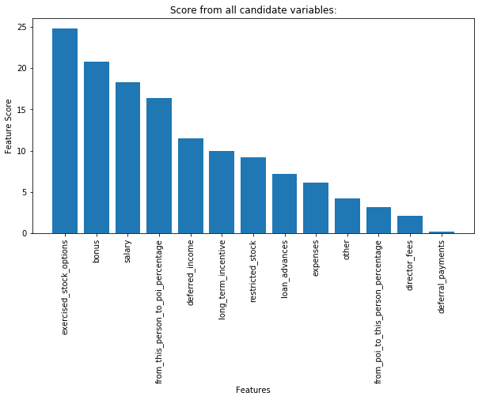

```python
test_kbest = featureFormat(my_dataset, features_list, sort_keys=True)
labels, features = targetFeatureSplit(test_kbest)
###
kBest = SelectKBest(k= 'all')
kBest.fit_transform(features, labels)
kResult = zip(kBest.get_support(), kBest.scores_, features_list[1:])
list_res = list(kResult)
res = sorted(list_res, key = lambda x: x[1], reverse = True)
scores = zip(*res)[1]
features = zip(*res)[2]
x_pos = np.arange(len(scores))

plt.figure(figsize=(10,5))
plt.bar(x_pos, scores,align='center')
plt.xticks(x_pos, features, rotation = 90)
plt.xlabel('Features')
plt.title('Score from all candidate variables:')
plt.ylabel('Feature Score')
plt.show()
```

```python
print "Score from all candidate variables:", res
```

[output not shown]

Once I have checked the score associated to each feature, I decided to try with the best 5 features due their value is bigger than >10 so I considered they have enough importance to be considered, now I will evaluate how it works for different algorithms using the sample.

```python
features_list = ['poi']
for i in range(5):
    features_list.append(res[i][2])

print "Final list of candidates to be included in the model" , features_list[0:]
```

```
Final list of candidates to be included in the model ['poi', 'exercised_stock_options', 'bonus', 'salary', 'from_this_person_to_poi_percentage', 'deferred_income']
```

#### Q3: What algorithm did you end up using? What other one(s) did you try? How did model performance differ between algorithms? [relevant rubric item: “pick an algorithm”]

Before I decide which algorithm I will use, I will check how they work using the data from the sample.

```python
%run poi_id.py
```

```
--------------GAUSSIAN NB CLASSIFIER-------------------
GAUSSIAN NB CLASSIFIER
Accuracy:  0.92
Precision:  0.6
Recall:  0.6
F1 score:  0.6
[[41  2]
 [ 2  3]]
Predicted  0.0  1.0  All
True
0.0         41    2   43
1.0          2    3    5
All         43    5   48
None
--------------K-NEIGHBOURS CLASSIFIER-------------------
K-NEIGHBOURS CLASSIFIER
Accuracy:  0.9
Precision:  0.0
Recall:  0.0
F1 score:  0.0
[[43  0]
 [ 5  0]]
Predicted  0.0  All
True
0.0         43   43
1.0          5    5
All         48   48
None
-------------- ADABOOST CLASSIFIER-------------------
ADABOOST CLASSIFIER
Accuracy:  0.88
Precision:  0.33
Recall:  0.2
F1 score:  0.25
[[41  2]
 [ 4  1]]
Predicted  0.0  1.0  All
True
0.0         41    2   43
1.0          4    1    5
```

[output cut: 15 more lines]

```
None
--------------DECISION TREE CLASSIFIER-------------------
DECISION TREE CLASSIFIER
Accuracy:  0.88
Precision:  0.33
Recall:  0.2
F1 score:  0.25
[[41  2]
 [ 4  1]]
Predicted  0.0  1.0  All
True
0.0         41    2   43
1.0          4    1    5
All         45    3   48
None
```

After reviewing the results from the sample I decided to try with Adaboost, Decision Tree, Random Forest and Gaussian NB classifier which are the algorithms with better results. Now I will run them using the whole dataset.

#### Q4: What does it mean to tune the parameters of an algorithm, and what can happen if you don’t do this well? How did you tune the parameters of your particular algorithm? What parameters did you tune? (Some algorithms do not have parameters that you need to tune -- if this is the case for the one you picked, identify and briefly explain how you would have done it for the model that was not your final choice or a different model that does utilize parameter tuning, e.g. a decision tree classifier). [relevant rubric items: “discuss parameter tuning”, “tune the algorithm”]

In machine learning, the specific model used is a function and requires parameters in order to make a prediction on new data. Each parameter is a function argument that help to optimize the function and provide better results for the model. There are some existing tools which explore a range of possibilities for each parameter and select automatically the best parameters for each model increasing their performance, this process is called to tune a model hyperparameter, one of this, it's GridSearch. The grid search algorithm works following the next steps:

- Selecting a set of hyperparameters and the values you want to test for each hyperparameter.
- Running an exhaustive search over all possible combinations of these values
- Training one model for each set of values.
- Comparing the scores of each model.
- Keeping the best one.

Therefore, I will tune the algorithms that I previously select and check the results.

```python
%run tester.py
```

```
GaussianNB(priors=None, var_smoothing=1e-09)
	Accuracy: 0.86014	Precision: 0.51549	Recall: 0.34950	F1: 0.41657	F2: 0.37356
	Total predictions: 14000	True positives:  699	False positives:  657	False negatives: 1301	True negatives: 11343
```

For Decision Tree, first step is to search for the best hyperparameters using Gridsearch.

```python
param_grid_dt = {'criterion': ['gini','entropy'],
              'min_samples_leaf': [2,4,8,16,32],
              'max_depth': [1,2,5,10,15],
              'min_samples_split' : [2,4,6,10,20,30]
               }

clf_dt = tree.DecisionTreeClassifier()
clf_dt_grid = GridSearchCV(clf_dt, param_grid_dt)
model_clf_dt = clf_dt_grid.fit(features_train, labels_train)

from pprint import pprint
pprint(model_clf_dt.best_estimator_.get_params())  #this line showed to me the best parameters for DT model.
```

```
{'class_weight': None,
 'criterion': 'gini',
 'max_depth': 1,
 'max_features': None,
 'max_leaf_nodes': None,
 'min_impurity_decrease': 0.0,
 'min_impurity_split': None,
 'min_samples_leaf': 16,
 'min_samples_split': 2,
 'min_weight_fraction_leaf': 0.0,
 'presort': False,
 'random_state': None,
 'splitter': 'best'}
```

Using the following parameters I obtained the following result for Decision Tree classifier:

```python
%run tester.py
```

```
DecisionTreeClassifier(class_weight=None, criterion='gini', max_depth=1,
            max_features=None, max_leaf_nodes=None,
            min_impurity_decrease=0.0, min_impurity_split=None,
            min_samples_leaf=16, min_samples_split=2,
            min_weight_fraction_leaf=0.0, presort=False, random_state=None,
            splitter='best')
	Accuracy: 0.83471	Precision: 0.11893	Recall: 0.02450	F1: 0.04063	F2: 0.02913
	Total predictions: 14000	True positives:   49	False positives:  363	False negatives: 1951	True negatives: 11637
```

For AdaBoost, first step is to search for the best hyperparameters using Gridsearch.

```python
param_grid_ada  = {
              'n_estimators': [50,150,250,500],
              'algorithm': ['SAMME', 'SAMME.R'],
              'learning_rate': [0.2, .5, 1, 1.5, 2.],
              }
```

```python
clf_ada = AdaBoostClassifier()
clf_adagrid = GridSearchCV(clf_ada, param_grid_ada , cv =5)
clf_adagrid.fit(features_train, labels_train)

from pprint import pprint
pprint(clf_adagrid.best_estimator_.get_params())
```

```
{'algorithm': 'SAMME',
 'base_estimator': None,
 'learning_rate': 0.2,
 'n_estimators': 50,
 'random_state': None}
```

Using the following parameters I obtained the following result for Adaboost classifier:

```python
%run tester.py
```

```
AdaBoostClassifier(algorithm='SAMME', base_estimator=None, learning_rate=0.2,
          n_estimators=50, random_state=None)
	Accuracy: 0.86521	Precision: 0.61554	Recall: 0.15050	F1: 0.24186	F2: 0.17729
	Total predictions: 14000	True positives:  301	False positives:  188	False negatives: 1699	True negatives: 11812
```

In addition, I've tried with Random Forest algorithm but the time for training and predictions were too high, so I decided to discard this algorithm as a good option.

GaussianNB was the algorithm with the best perfomance and which meet with all the specifications of the project. Although Adaboost classifier with tuned parameters have a better precision metric, the recall is very low, so Gaussian NB was priorized.

#### Q5: What is validation, and what’s a classic mistake you can make if you do it wrong? How did you validate your analysis? [relevant rubric items: “discuss validation”, “validation strategy”].

In machine learning, model validation is referred to the process where a trained model is evaluated with a testing data set. The testing data set is a separate portion of the same data set from which the training set is derived. In this project, the testing data set represents the 0.33 of the whole dataset. The main goal of using the testing data set is to evaluate the generalization ability of a trained model, in other words, validation is used to get the error rate of a machine learning model.

A classic mistake in validation process is overfitting. This is a modeling error which happens when a function is too closely fit to a specific set of data points. This situation is easily identified when the model is able to fit almost perfectly the training data but is performing poorly on new data.

The tester.py script use StratifiedShuffleSplit cross validator using folds=1000 which provide the metrics showed for each classifier.

#### Q6: Give at least 2 evaluation metrics and your average performance for each of them. Explain an interpretation of your metrics that says something human-understandable about your algorithm’s performance. [relevant rubric item: “usage of evaluation metrics”]

In this case, accuracy shows high percentage that make us think that our model is very good but we have to consider that the real number of POIs is very low in comparison with the number of NoN-POIs so, the situation is very unbalanced, for this reason the two evaluation metrics which can better determine how good is our model are precision and recall. If I had high value for precision that would means that when my classifier predict a person like POI, there are many probabilities that this person was a real POI and not a false alarm. Similarly, if I had high value for recall would mean my classifier is capable to identify a high number of POIs over all true existing POIs.

In addition, F1 score can also be interpreted as a weighted average of the precision and recall so it is a relevant metric too.

Using Gaussian NB algorithm, I've obtained the following results: **Precision: 0.51549 Recall: 0.34950 F1: 0.41657**

Therefore, applying the context of the project we can affirm that:

**Almost 52% of people labeled by Gaussian NB classifer like persons of interest were really person of interest. In other words, the chance of a predicted POI by this classifier indeed being a POI is 52%, the other 48% predicted as POI were wrongly classified like POIs as they are Non-POIs.**

**Around 35% of persons of interest were identified using the Gaussian NB classifier. In other words, the ratio of cases correctly labeled POI over all true POI’s was about 35%.**

I decided to select the model with the higher recall as in my opinion it is the most important metric considering that the metric recall identify people who could have committed fraud in their work assignments, but I think the value should be closer to 1 than the one I've obtained, otherwise a lot of guilty people will never be catched!